# Taller Procesos aleatorios y descomposición

- Daniel Oviedo
- Juan Guayara

```python
repositorio = "https://github.com/jpospinalo/time-series.git"
```

```python
! pip install statsmodels
```

```python
# Librerias
import pandas as pd
import matplotlib.pyplot as plt
import numpy as np
import statsmodels.api as sm
from statsmodels.tsa.seasonal import seasonal_decompose, STL
```

## 1. Genere una muestra aleatoria de tamaño 1000 a partir de una distribución normal estándar. Visualice los datos como una serie de tiempo. ¿Verifique si se observa tendencia, comportamiento cíclico o estacional? Interprete los resultados.

```python
# Generar la muestra aleatoria de tamaño 1000
np.random.seed(42)
data = np.random.normal(0, 1, 1000)
```

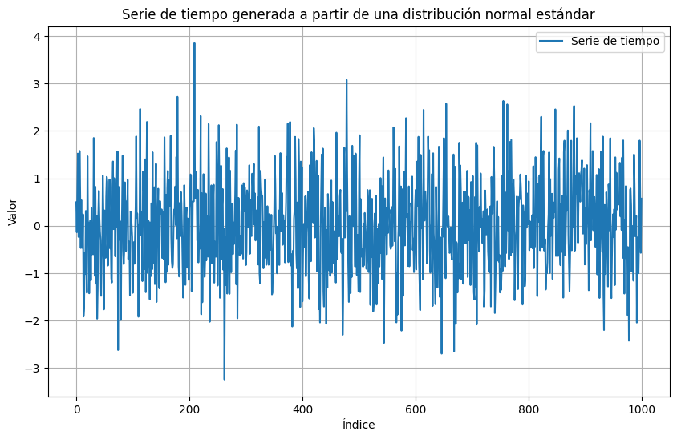

```python
# Crear un DataFrame para manejar los datos como serie de tiempo
df = pd.DataFrame(data, columns=['Value'])
df['Index'] = np.arange(1000)

# Graficar la serie de tiempo
plt.figure(figsize=(10,6))
plt.plot(df['Index'], df['Value'], label='Serie de tiempo')
plt.title('Serie de tiempo generada a partir de una distribución normal estándar')
plt.xlabel('Índice')
plt.ylabel('Valor')
plt.legend()
plt.grid(True)
plt.show()
```

Claramente, al ser una serie de tiempo generada de manera aleatoria con una distribución normal, no se espera que muestre tendencia ni estacionalidad o algún tipo de ciclos, esta gráfica no muestra ninguno de estos 3 comportamientos, y su varianza oscila cerca de la media, en este caso es 0.

## 2 .Obtenga los valores de autocorrelación para los primeros 100 retrasos del punto anterior y visualice el diagrama de autocorrelación. Interprete los resultados.

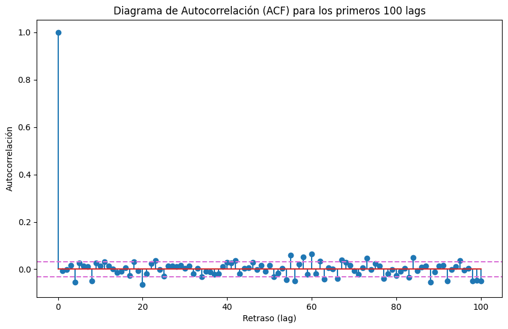

```python
# Calcular la autocorrelación para los primeros 100 retrasos (lags)
acf_values = sm.tsa.acf(df['Value'], nlags=100)

# Número de observaciones
N = len(df['Value'])

# Intervalos de confianza del 95%
conf_int = 1 / np.sqrt(N)

# Visualizar el diagrama de autocorrelación
plt.figure(figsize=(10,6))
plt.stem(range(101), acf_values, use_line_collection=True)

# Añadir los intervalos de confianza
plt.axhline(y=conf_int, color='orchid', linestyle='--', label='Intervalo de Confianza 95%')
plt.axhline(y=-conf_int, color='orchid', linestyle='--')

# Graficar
plt.title('Diagrama de Autocorrelación (ACF) para los primeros 100 lags')
plt.xlabel('Retraso (lag)')
plt.ylabel('Autocorrelación')
plt.show()
```

Teóricamente, los valores no deberían desviarse mucho de 0, ya que estamos usando una distribución normal estándar para generar los datos, el lag 0 presenta una correlación de 1 que es esperable, ya que se está comparando consigo misma, lo que claramente establece una autocorrelación perfecta. Basándonos en el gráfico si puede ver que efectivamente los resultados no se alejan mucho de 0 y se podría decir que no llegan ni a alcanzar el 0.1.

Sacando el analisis mirando el indice de confianza, se refuerza la idea de que los valores son totalmente aleatorios, puesto que obviando el primer valor, la gran mayoria de los datos se encuentran dentro del indice de confianza, lo que inidca que los valores son tan cercanos a cero que son casi que nulos, por lo que a la hora de encontrar una posible prediccion del futuro o una tendencia o ciclo, no se podria realizar.

## 3. Explique desde el punto de vista estadístico en que consiste el ruido blanco (en particular el ruido blanco Gausiano). Defina con sus palabras que podemos considerar un proceso aleatorio en el contexto de las series de tiempo.

Ruido Blanco desde el punto de vista Estadístico: El ruido blanco es un proceso aleatorio que representa una secuencia de variables aleatorias independientes e idénticamente distribuidas con una media de cero y varianza constante. El término "ruido" hace referencia a la parte impredecible o no explicada de un modelo.

Ruido Blanco Gaussiano: Es un caso particular del ruido blanco donde las variables aleatorias que lo componen siguen una distribución normal (o gaussiana). En este caso, cada observación se distribuye según una normal con media cero y varianza constante.

Proceso Aleatorio (Contexto en las series de tiempo): Es un proceso de variables aleatorio, pero que se indexa a lo largo del tiempo, ósea una variable aleatoria X en un instante de tiempo t.

- En otras palabras, se puede decir que el ruido blanco gaussiano es una frecuencia uniforme dentro de un rango específico, y la amplitud de su frecuencia sigue una distribución normal.

## 4. Cargue en un dataframe el archivo aus_livestock.csv disponible en este repositorio. Filtre los valores relacionados a la cantidad de cerdos sacrificados en el estado de Victoria para las fechas posteriores al 2014. Divida cada valor de la serie por mil para cambiar la escala a miles y visualice los datos como una serie de tiempo.

```python
dfLivestockRaw = "https://raw.githubusercontent.com/jpospinalo/time-series/main/aus_livestock.csv"
dfLivestock = pd.read_csv(dfLivestockRaw, index_col=0, parse_dates=True)
dfLivestock.head()
```

|  | Month | Animal | State | Count |
| --- | --- | --- | --- | --- |
| 1 | 1976 Jul | Bulls, bullocks and steers | Australian Capital Territory | 2300.0 |
| 2 | 1976 Aug | Bulls, bullocks and steers | Australian Capital Territory | 2100.0 |
| 3 | 1976 Sep | Bulls, bullocks and steers | Australian Capital Territory | 2100.0 |
| 4 | 1976 Oct | Bulls, bullocks and steers | Australian Capital Territory | 1900.0 |
| 5 | 1976 Nov | Bulls, bullocks and steers | Australian Capital Territory | 2100.0 |

```python
# Filtrar los datos: cerdos sacrificados en el estado de Victoria después de 2014
dfLivestock['Month'] = pd.to_datetime(dfLivestock['Month'], format='%Y %b')
filtered_df = dfLivestock[(dfLivestock['Animal'] == 'Pigs') &
                          (dfLivestock['State'] == 'Victoria') &
                          (dfLivestock['Month'] > '2014-12-31')]

filtered_df.head()
```

|  | Month | Animal | State | Count |
| --- | --- | --- | --- | --- |
| 24295 | 2015-01-01 | Pigs | Victoria | 87000.0 |
| 24296 | 2015-02-01 | Pigs | Victoria | 91000.0 |
| 24297 | 2015-03-01 | Pigs | Victoria | 99500.0 |
| 24298 | 2015-04-01 | Pigs | Victoria | 97800.0 |
| 24299 | 2015-05-01 | Pigs | Victoria | 99400.0 |

```python
# Cambiar la escala de los valores de 'Count' a miles
filtered_df['Count'] = filtered_df['Count'] / 1000
filtered_df.head()
```

|  | Month | Animal | State | Count |
| --- | --- | --- | --- | --- |
| 24295 | 2015-01-01 | Pigs | Victoria | 87.0 |
| 24296 | 2015-02-01 | Pigs | Victoria | 91.0 |
| 24297 | 2015-03-01 | Pigs | Victoria | 99.5 |
| 24298 | 2015-04-01 | Pigs | Victoria | 97.8 |
| 24299 | 2015-05-01 | Pigs | Victoria | 99.4 |

[figure not shown]

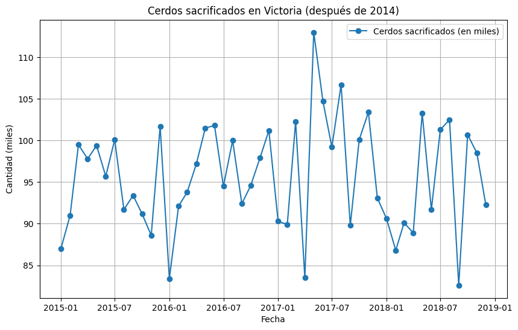

```python
# Visualizar la serie de tiempo
plt.figure(figsize=(10,6))
plt.plot(filtered_df['Month'], filtered_df['Count'], marker='o', label='Cerdos sacrificados (en miles)')
plt.title('Cerdos sacrificados en Victoria (después de 2014)')
plt.xlabel('Fecha')
plt.ylabel('Cantidad (miles)')
plt.legend()
plt.grid(True)
plt.show()
```

## 5. Obtenga los valores de autocorrelación para los primeros 30 retrasos del punto anterior y visualice el diagrama de autocorrelación. ¿Es posible identificar tendencia y estacionalidad en el gráfico de autocorrelación? Interprete los resultados.

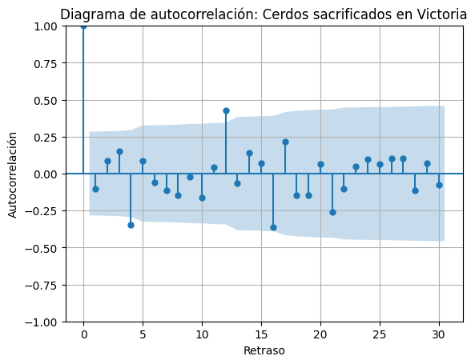

```python
from statsmodels.graphics.tsaplots import plot_acf

plt.figure(figsize=(10,6))
plot_acf(filtered_df['Count'], lags=30)
plt.title('Diagrama de autocorrelación: Cerdos sacrificados en Victoria')
plt.xlabel('Retraso')
plt.ylabel('Autocorrelación')
plt.grid(True)
plt.show()
```

- En el diagrama de autocorrelación se pueden observar muy pocos retrasos fuera del indice de confianza, lo que indica una autocorrelación fuerte en estos puntos, estos se encuentran en el lag 4 y 12, sin embargo, no se puede ver una tendencia o ciclicidad clara en los datos. Principalmente, se observa que luego de un pico alto, ya sea con autocorrelación positiva o negativa, esta tiende a estabilizarse cerca de 0.00, lo que indica que luego de realizar una cantidad grande de sacrificios en un mes, el siguiente mes, tienen que bajarle a la tasa de sacrifios, ya que si continuan con el mismo nivel de sacrificios, se puede generar una sobrecantidad de oferta, esto, a su vez, ocurre cuando hay picos muy bajos en un mes, al siguiente mes tienen que aumentar la cantidad de sacrificios para evitar que haya una posible sobredemanda.

## 6. Consulte la diferencia entre la función de autocorrelación y la función de autocorrelación parcial. Explique qué ventajas y desventajas tienen cada una.

ACF (Autocorrelación) y PACF (Autocorrelación Parcial) son herramientas fundamentales en el análisis de series temporales que nos ayudan a entender las relaciones entre los valores de una serie en diferentes puntos del tiempo.

ACF: Mide la correlación entre un valor y sus valores anteriores, considerando todas las correlaciones intermedias. Es útil para identificar patrones generales como tendencias o estacionalidad. PACF: Mide la correlación directa entre un valor y un valor anterior específico, eliminando el efecto de las correlaciones intermedias. Es ideal para identificar el orden de los modelos AR (Autorregresivos) y ver las relaciones directas entre los retrasos. En resumen:

ACF: Visión general de las correlaciones, útil para patrones globales. PACF: Correlaciones directas, ideal para modelos AR y relaciones específicas. Cuándo usar cada una:

ACF: Para detectar tendencias, estacionalidad y patrones generales. PACF: Para identificar el número de términos autorregresivos en un modelo AR y ver las relaciones directas entre los retrasos.

## 7. Cargue en un dataframe el archivo aus_retail.csv disponible en este repositorio. Filtre los valores para los valores de “Food Retailing” en la columna “Industry”. Los datos presentan valores para varios estados en las mismas fechas. Sume los valores de la columna “Turnover” para todos los estados según la fecha y visualice el resultado como una serie de tiempo. ¿Analice la tendencia, la estacionalidad y la variación de la serie?

```python
dfRetailRaw = "https://raw.githubusercontent.com/jpospinalo/time-series/main/aus_retail.csv"
dfRetail = pd.read_csv(dfRetailRaw, index_col=0, parse_dates=True)
dfRetail.head()
```

|  | State | Industry | Series ID | Month | Turnover |
| --- | --- | --- | --- | --- | --- |
| 1 | Australian Capital Territory | Cafes, restaurants and catering services | A3349849A | 1982 Apr | 4.4 |
| 2 | Australian Capital Territory | Cafes, restaurants and catering services | A3349849A | 1982 May | 3.4 |
| 3 | Australian Capital Territory | Cafes, restaurants and catering services | A3349849A | 1982 Jun | 3.6 |
| 4 | Australian Capital Territory | Cafes, restaurants and catering services | A3349849A | 1982 Jul | 4.0 |
| 5 | Australian Capital Territory | Cafes, restaurants and catering services | A3349849A | 1982 Aug | 3.6 |

```python
# Convertir la columna 'Month' en tipo de dato datetime
dfRetail['Month'] = pd.to_datetime(dfRetail['Month'], format='%Y %b')

# Establecer 'Month' como el índice del DataFrame
dfRetail.set_index('Month', inplace=True)
```

```python
# Filtrar los datos para "Food Retailing"
dfFoodRetailing = dfRetail[dfRetail['Industry'] == 'Food retailing']

# Sumar el 'Turnover' para todos los estados según la fecha
dfFoodRetailingSum = dfFoodRetailing.groupby(dfFoodRetailing.index).agg({'Turnover': 'sum'})
```

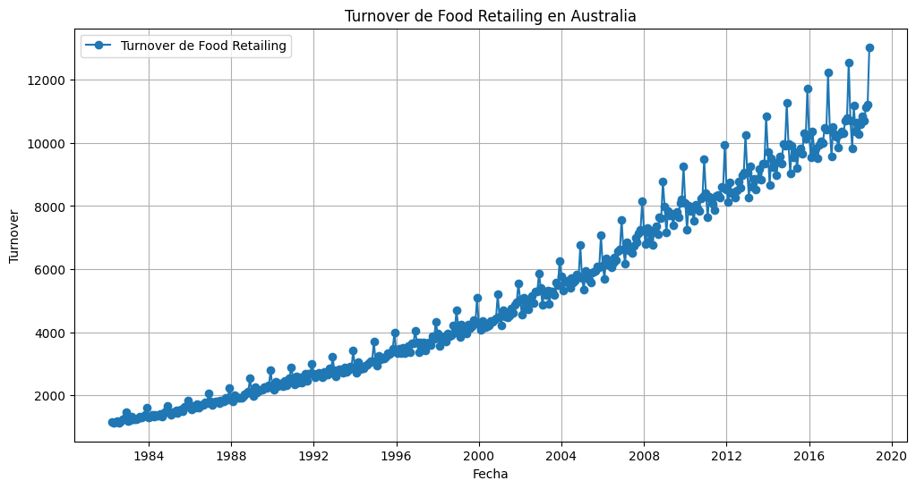

```python
# Visualizar la serie de tiempo
plt.figure(figsize=(12,6))
plt.plot(dfFoodRetailingSum.index, dfFoodRetailingSum['Turnover'], marker='o', label='Turnover de Food Retailing')
plt.title('Turnover de Food Retailing en Australia')
plt.xlabel('Fecha')
plt.ylabel('Turnover')
plt.legend()
plt.grid(True)
plt.show()
```

- A lo largo de la serie de tiempo, se observa una clara tendencia positiva con el paso de los años y una estacionalidad, puesto que en cada año se puede ver un el pico mas alto en ese año y consecuentemente un el pico mas bajo en ese año. Adicionalmente, se ve tambien como la varianza tiende a ser mayor a medida que la serie de tiempo avanza, lo que indica una relacion directamente proporcional con respecto a la tendencia en la serie

## 8. Realice dos transformaciones sobre la serie obtenida en el punto anterior. La primera aplicando la función raíz cuadrada y la segunda aplicando la función logaritmo. ¿Qué cambios es posible observar en las series resultantes? ¿Qué ventajas tendría trabajar con los datos transformados?

```python
# Transformación de raíz cuadrada
dfFoodRetailingSum['Turnover_sqrt'] = np.sqrt(dfFoodRetailingSum['Turnover'])

# Transformación logarítmica
dfFoodRetailingSum['Turnover_log'] = np.log(dfFoodRetailingSum['Turnover'] + 1)
```

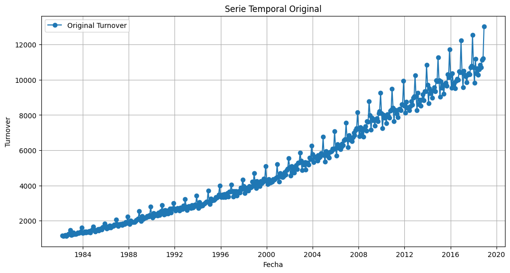

```python
# Gráfico original
plt.figure(figsize = (12, 6))
plt.plot(dfFoodRetailingSum.index, dfFoodRetailingSum['Turnover'], marker='o', label='Original Turnover')
plt.title('Serie Temporal Original')
plt.xlabel('Fecha')
plt.ylabel('Turnover')
plt.legend()
plt.grid(True)
plt.show()
```

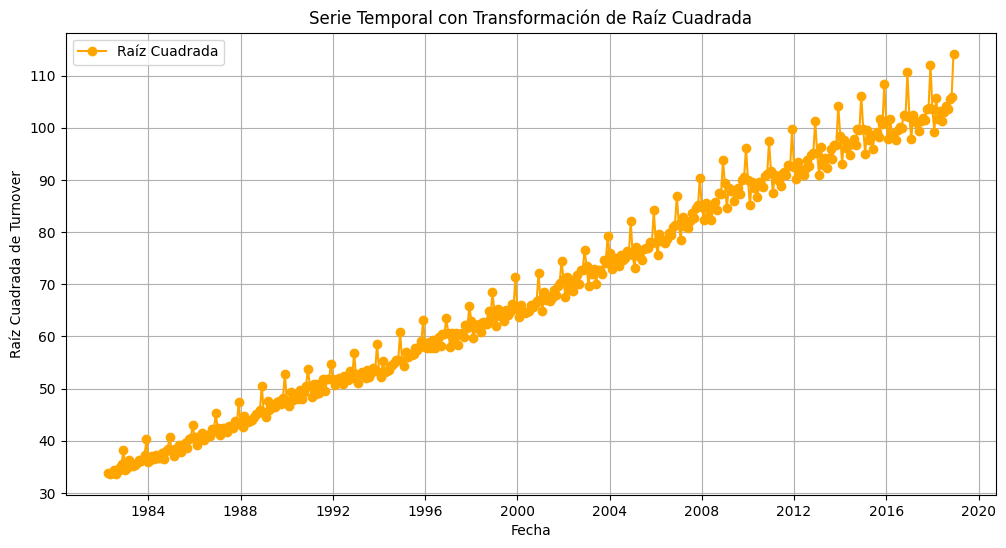

```python
# Gráfico raíz cuadrada
plt.figure(figsize = (12, 6))
plt.plot(dfFoodRetailingSum.index, dfFoodRetailingSum['Turnover_sqrt'], marker='o', color='orange', label='Raíz Cuadrada')
plt.title('Serie Temporal con Transformación de Raíz Cuadrada')
plt.xlabel('Fecha')
plt.ylabel('Raíz Cuadrada de Turnover')
plt.legend()
plt.grid(True)
plt.show()
```

Se observa una varianza mucho mejor estabilizada que en grafico original, adicionalmente se puede empezar a ver un comportamiento ciclico ligeramente luego del año 2009.

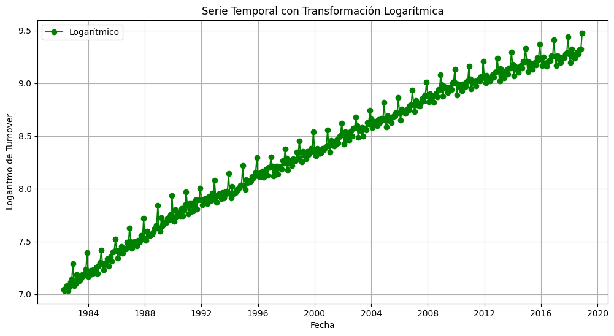

```python
# Gráfico logarítmico
plt.figure(figsize = (12, 6))
plt.plot(dfFoodRetailingSum.index, dfFoodRetailingSum['Turnover_log'], marker='o', color='green', label='Logarítmico')
plt.title('Serie Temporal con Transformación Logarítmica')
plt.xlabel('Fecha')
plt.ylabel('Logaritmo de Turnover')
plt.legend()
plt.grid(True)
plt.show()
```

Se puede observar una varianza mucho más estabilizada que en el grafico original y que en la transformacion con raiz cuadrada. Con esta transformacion se hace mucho mas evidente las tendencias a lo largo de toda la serie de tiempo, observando una ciclicidad a lo largo de toda la serie, pero, con ciertas variaciones en uno que otro año, como entre 1997 y 1999.

## 9. Consulte en que consiste la transformación de Box-Cox; con qué propósito se usa y apliqué dicha transformación a los datos del punto 7. Compare los resultados con los obtenidos con las transformaciones del punto 8.

```python
from scipy import stats

# Aplicamos la transformación de Box-Cox
turnover_boxcox, lambda_bc = stats.boxcox(dfFoodRetailingSum['Turnover'])

# Agregamos la serie transformada al DataFrame
dfFoodRetailingSum['Turnover_boxcox'] = turnover_boxcox

# Imprimimos el valor de lambda que maximiza la normalidad
print(f"Lambda óptimo para la transformación Box-Cox: {lambda_bc}")
```

```
Lambda óptimo para la transformación Box-Cox: 0.24936902926292065
```

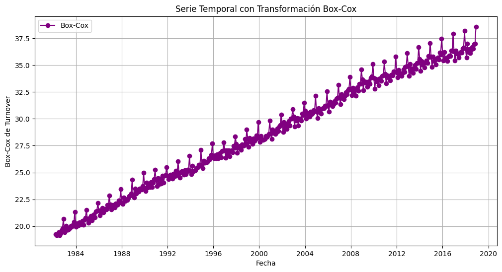

```python
plt.figure(figsize = (12, 6))
plt.plot(dfFoodRetailingSum.index, dfFoodRetailingSum['Turnover_boxcox'], marker='o', color='purple', label='Box-Cox')
plt.title('Serie Temporal con Transformación Box-Cox')
plt.xlabel('Fecha')
plt.ylabel('Box-Cox de Turnover')
plt.legend()
plt.grid(True)
plt.show()
```

- Para este caso, usar box-cox puede ser ideal puesto que la varianza no es constante a lo largo de la serie de tiempo y, usar estas funciones nos ayuda a que se estabilice a lo largo de toda la serie (pese a que depende de 𝜆, es muy parecida la transformacion que realiza box-cox con la que se realizo anteriormente de manera logaritmica, esto se explicara porque más adelante)

Efecto: Box-Cox ajusta automáticamente la transformación para optimizar la normalización y estabilización de la varianza, aplicando una combinación de transformaciones (dependiendo del valor de 𝜆.)

En la práctica es una técnica flexible que puede ser vista como una combinación de las anteriores (raíz cuadrada y logarítmica). Además, puede ajustarse a diferentes tipos de series temporales de manera óptima.

## 10. Cargue en un dataframe el archivo us_employment.csv disponible en este repositorio. Filtre los valores de la columna “Employed” para fechas superiores a 1990 y asociados con valores “Retail Trade” de la columna “Title”. Visualice los datos como una serie de tiempo.

```python
dfemploymentRaw = "https://raw.githubusercontent.com/jpospinalo/time-series/main/us_employment.csv"
dfemployment = pd.read_csv(dfemploymentRaw, index_col=0, parse_dates=True)
dfemployment.head()
```

|  | Month | Series_ID | Title | Employed |
| --- | --- | --- | --- | --- |
| 1 | 1939 Jan | CEU0500000001 | Total Private | 25338.0 |
| 2 | 1939 Feb | CEU0500000001 | Total Private | 25447.0 |
| 3 | 1939 Mar | CEU0500000001 | Total Private | 25833.0 |
| 4 | 1939 Apr | CEU0500000001 | Total Private | 25801.0 |
| 5 | 1939 May | CEU0500000001 | Total Private | 26113.0 |

```python
# Convertir la columna "Month" a tipo datetime. La columna contiene el año y el mes (formato '1939 Jan', '1939 Feb', etc.)
dfemployment['Month'] = pd.to_datetime(dfemployment['Month'], format='%Y %b')

# Establecer la columna "Month" como índice del DataFrame para trabajar como serie de tiempo
dfemployment.set_index('Month', inplace=True)
```

```python
# Filtrar los datos para aquellos registros a partir de 1990 y para la categoría "Retail Trade"
df_filtered = dfemployment[(dfemployment.index.year > 1990) & (dfemployment['Title'] == 'Retail Trade')]
```

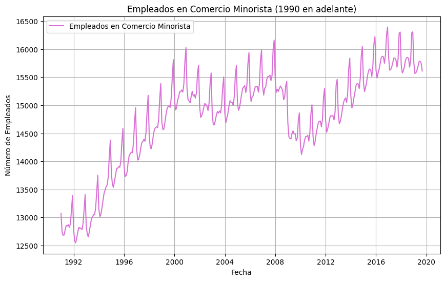

```python
# Visualización de la serie de tiempo de la columna "Employed"
plt.figure(figsize=(10,6))  # Configura el tamaño de la figura
plt.plot(df_filtered.index, df_filtered['Employed'], label='Empleados en Comercio Minorista', color='orchid')
plt.title('Empleados en Comercio Minorista (1990 en adelante)')
plt.xlabel('Fecha')
plt.ylabel('Número de Empleados')
plt.legend()
plt.grid(True)
plt.show()
```

## 11. A partir de la gráfica generada en el punto anterior, identifique la tendencia, el comportamiento cíclico y el comportamiento estacional. Realice esta tarea únicamente mediante inspección visual.

**Tendencia**:

- Se puede evidenciar una tendencia postivia en el comportamiento de la serie de tiempo, no obstante, ocurre una caida fuerte en la cantidad de empleados en el año 2009, esto puede deberse a los ataques terroristas, la llegada de obama a la presidencia. No obstante, luego de esta caida, vuelve con la tendencia encontrada en los años previos.

**Ciclicidad**:

- A lo largo de toda la serie de tiempo, se puede ver una notoria ciclicidad con periodos estacionales a lo largo de cada año. Este ciclo se repite a lo largo de toda la serie, teniendo el pico más alto y luego decreciendo, hasta que inicia el siguiente año y vuelve a encontrarse el mismo comportamiento, exceptuando el año 2009, todos los años se evidencia la misma tendencia.

## 12 . Consulte en que consiste la descomposición de una serie de tiempo. Explique en qué casos se puede utilizar la descomposición aditiva y cuando la multiplicativa. Presente un ejemplo de cada una. ¿Explique qué representan los residuos en la descomposición? ¿Cuál sería el comportamiento esperado?

**Descomposición en una serie de tiempo**

Esta consiste principalmente en descomponer cuatro componentes principales presentes en la serie de tiempo, este proceso se realiza para poder tener un analisis más detallado y analizar y entender mejor las tendencias y diversos patrones que tenga la serie de tiempo.

1. **Tendencia**:
- Esta representa el comportamiento a largo plazo de la serie de tiempo
- Indica si los valores aumentan, disminuyen o mantienen el mismo valor
2. ** Estacionalidad**:
- Las variaciones periodicas que se repiten de manera regular en un periodo de tiempo no mayor a un año
- Las fluctuaciones periodicas suelen estar vinculadas con algun fenomeno que ocurre en intervalos regulares, como un posible aumento de ventas en temporada navideña o menor cantidad de ventas en periodos vacacionales.
3. **Ciclicidad**:
- Fluctuaciones que no ocurren en intervalos regulares
- Los ciclos de la serie de tiempo son las fluctuaciones que se repiten de manera regular en un periodo de tiempo mayor a un año
- Estos ciclos estan asociados con cambios a largo plazo, como ciclos economicos
- Su duracion y magnitud no pueden ser predecibles (mayor diferencia frente a la estacionalidad)
4. **Ruido**:
- Es el componente irregular de la serie de tiempo
- Refleja las variaciones que no pueden ser explicadas por algun otro componente en la serie de tiempo.
- Estas fluctuaciones no pueden ser predecibles

La Descomposición aditiva es util de usar cuando la estacionalidad tiene la misma magnitud en toda la serie, sin importar el nivel general de la tendencia (estacionalidad constante en toda la serie).

Un ejemplo de cuando usar la Descomposición aditiva es cuando hay un aumento de ventas en diciembre por fiestas, lo que es una magnitud consistente cada año, independiente si las ventas han estando bien o mal a lo largo de todo el año.

La Descomposición multiplicativa es util cuando la estacionalidad y el ruido cambian proporcionalmente con el nivel de la tendencia. Si la tendencia crece, las fluctuaciones estacionales y el ruido también lo hacen proporcionalmente.

Un ejemplo de cuandp usar descomposicion multiplicativa es cuando en una ciudad, durante la temporada alta de verano, la cantidad de turistas crece, lo que a su vez, tambien hace crecer la tasa de turismo anual, por otra parte, cuando todos los turistas dejan de viajar a ese sitio por lo que es temporada baja, la tasa de turismo anual baja a su vez.

## 13. Utilice la función seasonal_decompose() del módulo tsa de statmodels para realizar una descomposición aditiva de la serie obtenida en el punto cuatro. Visualice todos los componentes y compare los resultados con los obtenidos a través de la inspección visual. Verifique las escalas de cada una de las gráficas y explique la diferencia en los valores.

```python
filtered_df.head()
```

|  | Month | Animal | State | Count |
| --- | --- | --- | --- | --- |
| 24295 | 2015-01-01 | Pigs | Victoria | 87.0 |
| 24296 | 2015-02-01 | Pigs | Victoria | 91.0 |
| 24297 | 2015-03-01 | Pigs | Victoria | 99.5 |
| 24298 | 2015-04-01 | Pigs | Victoria | 97.8 |
| 24299 | 2015-05-01 | Pigs | Victoria | 99.4 |

```python
# Convertir en indice la serie de tiempo del punto 4
filtered_df.set_index('Month', inplace=True)
```

```python
serie_tiempo = filtered_df['Count']
serie_tiempo.head()
```

```
Month
2015-01-01    87.0
2015-02-01    91.0
2015-03-01    99.5
2015-04-01    97.8
2015-05-01    99.4
Name: Count, dtype: float64
```

```python
# Realizar la descomposición aditiva
result = seasonal_decompose(serie_tiempo, model='additive')
```

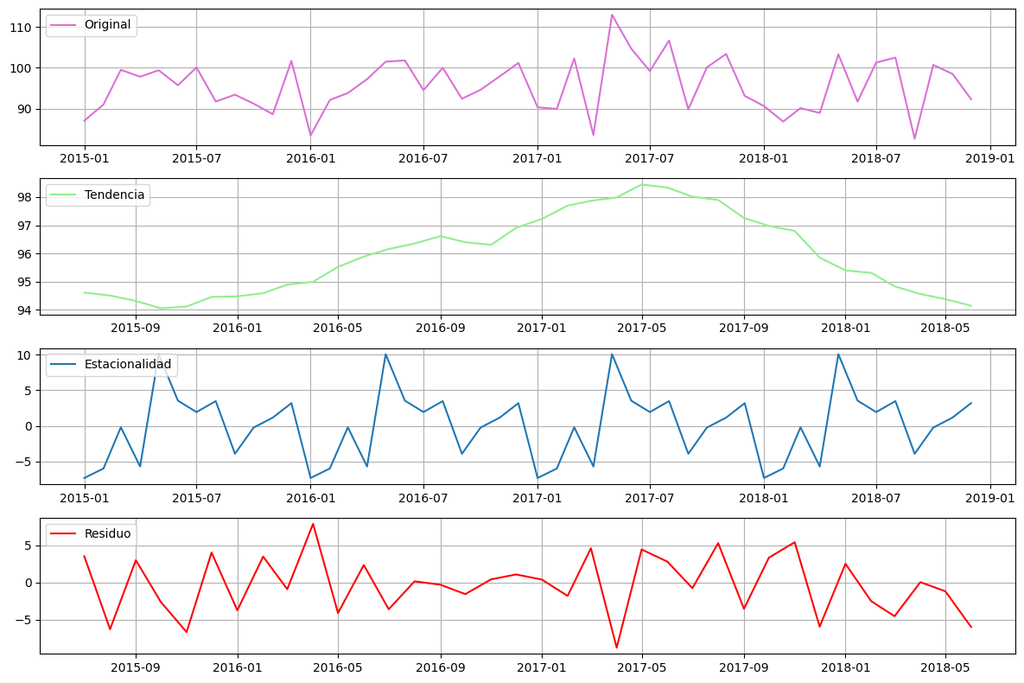

```python
# Graficar los componentes de la descomposición
plt.figure(figsize=(12, 8))
plt.subplot(411)
plt.grid(True)
plt.plot(filtered_df['Count'], label='Original', color="orchid")
plt.legend(loc='upper left')

plt.subplot(412)
plt.grid(True)
plt.plot(result.trend, label='Tendencia', color="lightgreen")
plt.legend(loc='upper left')

plt.subplot(413)
plt.grid(True)
plt.plot(result.seasonal, label='Estacionalidad')
plt.legend(loc='upper left')

plt.subplot(414)
plt.grid(True)
plt.plot(result.resid, label='Residuo', color='red')
plt.legend(loc='upper left')

plt.tight_layout()
plt.show()
```

## 14. Consulte la diferencia entre la descomposición STL y la descomposición clásica de los componentes de una serie de tiempo. Presente las ventajas y desventajas de cada método y muestre en qué casos sería preferible utilizar un método sobre otro.

**Descomposición Clasica**:

- Esta escomposición es una tecnica que se basa en un modelo predefinido, como el aditivo o el multiplicativo.
- Aditivo:$Y_t = T_t + S_t + R_t$
- Multiplicativo: $Y_t = T_t \times S_t \times R_t$

Donde:

[output not shown]

Utilizar este tipo de descomposición tiene ciertas ventajas

```
* Es simple y rapida de implementar, usando metodos basados en suavizamiento exponencial o media movil (multiplicativo o aditivo)

* Cuenta con varias bibliotecas para ser implementada

* Funciona mejor cuando la estacionalidad es constante (modelo aditivo principalmente)
```

Tambien trae ciertas desventajas:

```
* Al asumir que la estacionalidad es fija, no puede adaptarse a patrones de estacionalidad cambiantes o no lineales

* Si se encuentran muchos valores atipicos, se puede distorsionar en gran medidad la estimacion de componentes.
```

**Descomposición STL**:

- Esta descomposición es un metodo más flexible puesto que usa el ajuste local de regresion por suavizamiento (LOESS)

Tiene ventajas:

```
* Permite que la estacionalidad varie a lo largo del tiempo, adaptandose mejor a patrones cambiantes

* Usa metodos de suavizamiento robustos que reducen el impacto de valores atipicos

* Proporciona parametros de control para ajustar la suavidad de la tendencia y estacionalidad

* Se puede usar con datos con estacionalidad multiple o patrones estacionales complejos.
```

Tambien trae ciertas desventajas:

```
* Requiere un costo computacional mayor

* Requiere ajustar varios parametros, lo que, si no se realiza adecuadamente, puede generar resultados inesperados.
```

¿Cuando usar cada metodo?

**Clasica**

Cuando la serie de tiempo presenta un patron estacional constante en amplitud y regular en su periodicidad (ventas minoristas que presentan mayor cantidad de ventas en diciembre)

Cuando la serie tiene pocos valores atipicos o ruidos (Produccion de una fabrica automatizada, con flucutaciones minimas y sin interrupciones)

Cuando se necesita de una descomposicion rapida y sencilla sin necesidad de personalizacion de parametros (Revision rapida de datos historicos para una estimacion inicial)

Cuando se dispone de una serie de tiempo larga y con suficientes datos para capturar el patron estacional a lo largo de varios periodos (Datos metereologicos que muestren patrones estacionales consistentes)

**STL**

Cuando la serie presenta patrones estacionales que varian con el tiempo (Trafico en la web de la sergio arboleda, que presentan periodos estacionales más grandes cuando hay inscripciones de materias)

Cuando los datos contienen bastante ruido que pueda afectar la serie de tiempo (Como en el punto 4)

Cuando se necesite de un control detallado sobre como se suavizan los componentes de tendencia y estacionalidad (Un analisis financiero donde es cruciar ajustar precisamente la tendencia para poder predecir cambios en el mercado)

Cuando los datos tienen multilples patrones estacionales (Consumo de energia electrica)

## 15. Utilice la función STL() del módulo tsa.seasonal de statmodels para realizar una descomposición de los datos mencionados en el punto 10. Visualice todos los componentes de la serie de tiempo para las dos descomposiciones utilizadas; STL y la descomposición aditiva. Realice un gráfico en donde pueda apreciarse cada uno de los componentes generados por cada método de forma simultánea.

```python
df_filtered
```

| Month | Series_ID | Title | Employed |
| --- | --- | --- | --- |
| 1991-01-01 | CEU4200000001 | Retail Trade | 13068.3 |
| 1991-02-01 | CEU4200000001 | Retail Trade | 12744.2 |
| 1991-03-01 | CEU4200000001 | Retail Trade | 12684.5 |
| 1991-04-01 | CEU4200000001 | Retail Trade | 12687.0 |
| 1991-05-01 | CEU4200000001 | Retail Trade | 12780.6 |
| ... | ... | ... | ... |
| 2019-05-01 | CEU4200000001 | Retail Trade | 15691.6 |
| 2019-06-01 | CEU4200000001 | Retail Trade | 15775.5 |
| 2019-07-01 | CEU4200000001 | Retail Trade | 15785.9 |
| 2019-08-01 | CEU4200000001 | Retail Trade | 15749.5 |
| 2019-09-01 | CEU4200000001 | Retail Trade | 15611.3 |

345 rows × 3 columns

```python
# Descomposición aditiva
decomposition_add = seasonal_decompose(df_filtered['Employed'], model='additive', period=4)

# Descomposición STL
stl = STL(df_filtered['Employed'], seasonal=5)
decomposition_stl = stl.fit()
```

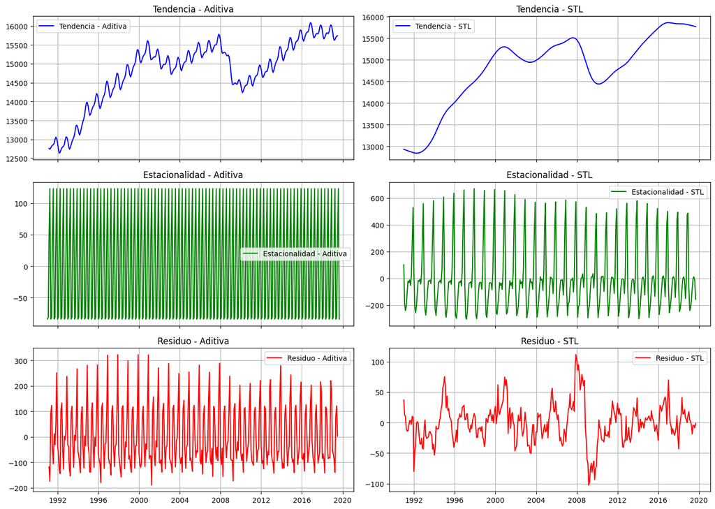

```python
# Visualización de las dos descomposiciones
fig, axes = plt.subplots(3, 2, figsize=(14, 10), sharex=True)

# Componentes de la descomposición aditiva
axes[0, 0].plot(decomposition_add.trend, label='Tendencia - Aditiva', color='blue')
axes[0, 0].set_title('Tendencia - Aditiva')
axes[1, 0].plot(decomposition_add.seasonal, label='Estacionalidad - Aditiva', color='green')
axes[1, 0].set_title('Estacionalidad - Aditiva')
axes[2, 0].plot(decomposition_add.resid, label='Residuo - Aditiva', color='red')
axes[2, 0].set_title('Residuo - Aditiva')

# Componentes de la descomposición STL
axes[0, 1].plot(decomposition_stl.trend, label='Tendencia - STL', color='blue')
axes[0, 1].set_title('Tendencia - STL')
axes[1, 1].plot(decomposition_stl.seasonal, label='Estacionalidad - STL', color='green')
axes[1, 1].set_title('Estacionalidad - STL')
axes[2, 1].plot(decomposition_stl.resid, label='Residuo - STL', color='red')
axes[2, 1].set_title('Residuo - STL')

# Mejorar visualización
for ax in axes.flat:
    ax.legend()
    ax.grid(True)

plt.tight_layout()
plt.show()
```

[figure not shown]